# Part II - Explanatory Data Analysis for Prosper Loan data

## by Opetunde Adepoju

## Investigation Overview

In this notebook, I wanted to find out which features were the best indicators for predicting the highest rate of return.

In the univariate exploration, I visualized and addressed minor quality and tidiness issues for the following features:

### Numerical Features

1. Estimated Returns
2. Actual Returns
3. Debt to Income Ratio

### Categorical Features

1. Income Range
2. Credit Grade The Actual Returns for the dataset was engineered from a simplified version of Prosper's Net Annualized formula.

The bivariate exploration revealed the numerical categories did not have any obvious correlations. When comparing the estimated returns with the income range and credit grade, it became apparent that the credit grade is a much better predictor for returns than the income range. The credit grade spanned every income range, however I noticed that borrowers with higher incomes often received better credit ratings.

The multivariate exploration revealed again that the credit rating was the best primary predictor for estimated returns. When introducing the loan status, loans that have been completed or are current followed a linear correlation between estimated and actual returns.

## Dataset Overview

Prosper is a P2P lending platform that allows investors to choose among personal loans to invest in. They do that by considering a number of factors, which include a custom calculated Prosper Score that represents the risk for each loan. The higher the score, the lower the risk, and the lower the interest rates paid by the borrower to the investors.

This data set contains 113,937 loans with 81 variables on each loan, including loan amount, borrower rate (or interest rate), current loan status, borrower income, and many others.

## Finding Actual Returns

To simplify our calculation for exploratory purposes, we will only divide by the original loan amount. We will run into other categorical issues if we try to determine the current rate of return for current loans vs completed loans etc. We may revisit this section to refine our actual returns feature.

There are some loans where it appears that the borrower never made a payment which gives us the minimum of losing 100% of the investment. On the other end of the spectrum, it looks like most loans drop off after about 170% of the original loan amount.

There appears to be different modes to the distribution. I will check to see how the actual returns are different from the loan status.

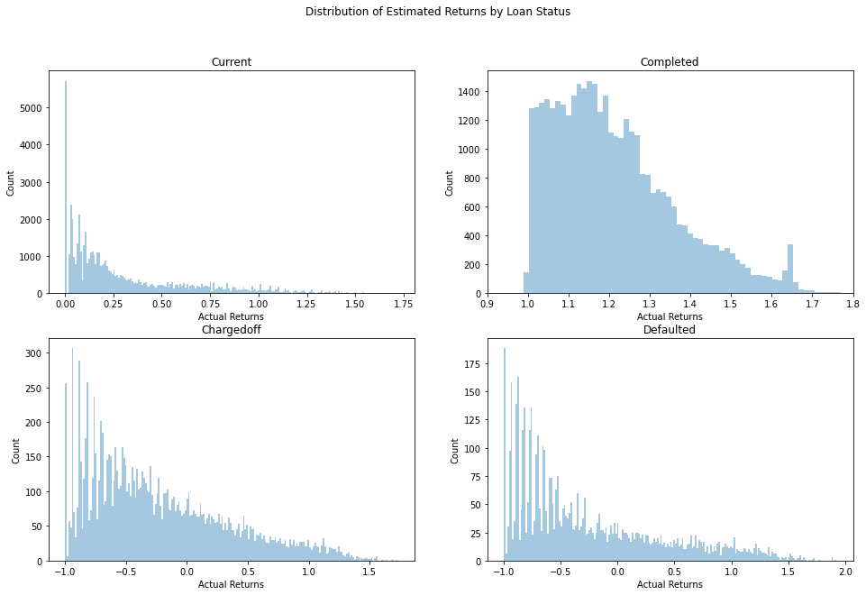

## Visualizing Prosper rating with credit grade

From the feature descriptions, it looks like Prosper transitioned to a "Prosper Rating" after 2009 to differentiate themselves from the industry standard "Credit Grade.

In the future we may want to look at estimated returns of the pre-2009 "Credit Grade" to see how it compares with the post-2009 "Prosper Rating" to validate if they truly are equivalent or if Prosper skewed their credit rating in some way.

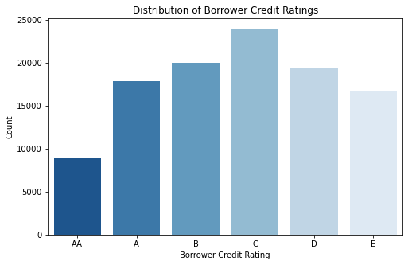

## Visualizing Income Range Analysis

There are a couple of features that are required for borrowers to be assigned these Credit Ratings. We'll start with taking a look at Income Ranges.

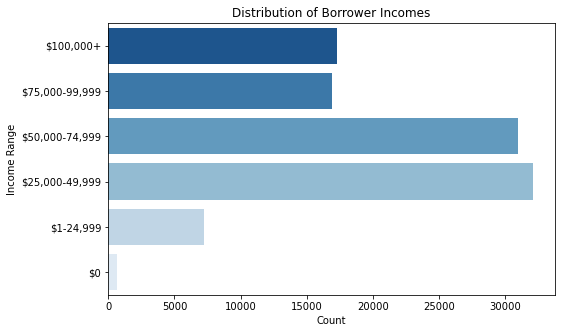

## Debt to Income Ratio

Of course your income is only part of the picture, let's see what the borrower's Debt to Income Ratio is like. I imagine a creditor wants to make sure you're not overleveraged in the event you have a loss of income and are unable to repay all of your debts. This will help us determine the distribution of their credit score.

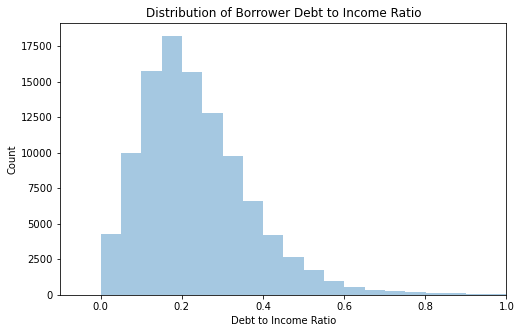

## Income range vs credit rating analysis

Let's take a look at how a borrower's income range and credit rating relates to the investor's estimated returns.

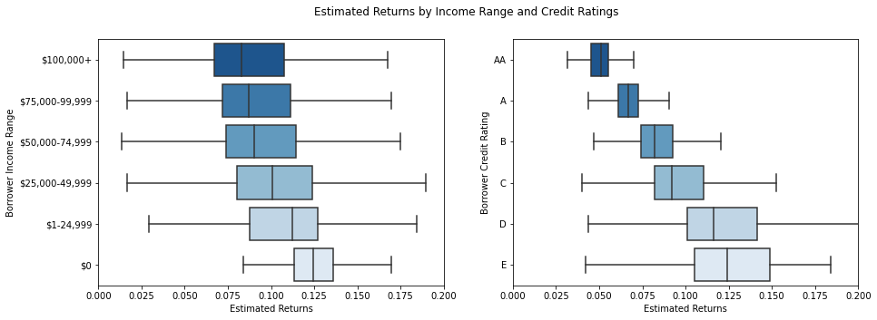